# Biostats Bootcamp — DAGs → Covariate Decisions → SEM (Winter Tick Example)

Troy Koser

2026-03-05

## 1 What we’re doing today (aka: why you should care)

So. Today we’re going to talk about **DAGs** (Directed Acyclic Graphs) and why they’re one of the cleanest ways to stop ourselves from doing that classic ecology thing where we:

- collect messy field data,
- open R,
- throw 14 covariates into a model,
- and then convince ourselves the *smallest p-value* is “the mechanism”.

DAGs are basically a way to write down your **causal assumptions** BEFORE you model anything. They’re not magic, or maybe they are? They won’t make your observational data causal, but they do force you to be honest about what you think is causing what, and that’s… a huge improvement!

Also: winter ticks are a great example system because **seasonality is the whole story**. Summer temp, fall questing season conditions, spring snow depth…all of that matters, and it matters in different directions at different stages.

## 2 Learning Goals

By the end of this lab, you should be able to:

- Explain what a **Directed Acyclic Graph (DAG)** is (in normal human words).
- Identify key DAG parts (nodes, arrows, paths, confounders, mediators, colliders).
- Use a DAG to decide **which environmental variables belong in a model** (and which ones are “bad controls”).
- Write a DAG in `dagitty`.
- Fit a simple **SEM** that matches the causal structure in the DAG using your simulated winter tick dataset.

## 3 What is a DAG?

A **Directed Acyclic Graph (DAG)** is a picture of a causal story.

Two defining properties:

- **Directed**
  - arrows represent assumed causal direction
  - example: `Fall temperature → questing window length → tick abundance`
- **Acyclic**
  - no loops
  - you can’t start at a variable and follow arrows and come back to it
  - (if your system has feedback loops… congrats, you’re doing science. For DAGs we usually simplify or pick a time window where our feedback loops won’t be present)

### 3.1 Why ecologists use DAGs (my version)

In ecology and disease ecology, we live in the land of:

- correlated environmental predictors (temp vs RH vs VPD vs prec… pick your fighter)
- messy observational data
- biological processes that are real but partly unmeasured

DAGs help because they:

- make your assumptions visible (to you and everyone else)
- clarify what you’re actually trying to estimate
- stop you from controlling for the wrong thing (colliders / mediators / post-treatment variables)
- help you justify covariate choices beyond “I saw it in a paper once”

## 4 Key parts of a DAG (terms you actually need)

- **Node**  
  A variable in the system (measured or unmeasured)
- **Directed edge (arrow)**  
  An assumed causal effect
- **Path**  
  Any connected sequence of arrows linking two nodes

The three big roles you need for “should I include this covariate?” decisions:

### 4.1 Confounder (common cause)

A variable that causes BOTH the exposure and the outcome.

If you don’t control it, you might get a fake relationship.

Example-ish:

```
Habitat → Host density
Habitat → Tick abundance
```

### 4.2 Mediator (on the causal chain)

A variable on the pathway from exposure → outcome.

If you control for it, you might block part of the effect you actually care about (depending on whether you want total vs direct effects).

Example:

```
Fall temp → Questing days → Tick abundance
```

### 4.3 Collider (common effect)

A variable caused by two things.

If you condition on a collider, you can *create* a relationship that wasn’t there.

Example:

```
Tick abundance → Hair loss amount ← Other stressors
```

## 5 Tiny schematic (toy DAG, just for labels)

This is not the winter tick DAG — it’s just a labeled sketch so we can point at things.

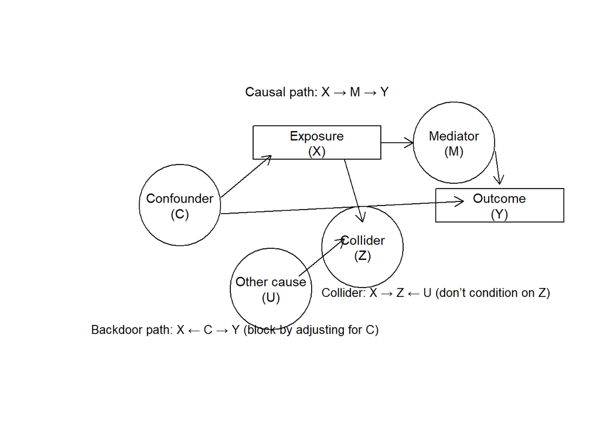

Toy DAG labeling exposure, outcome, confounder, mediator, and collider (base R schematic).

```r
plot(NA, xlim=c(0,10), ylim=c(0,6), axes=FALSE, xlab="", ylab="")

node <- function(x,y,label,box=FALSE){
  if(box){
    rect(x-1.4,y-0.4,x+1.4,y+0.4)
  } else {
    symbols(x,y,circles=0.9,add=TRUE,inches=FALSE)
  }
  text(x,y,label,cex=0.9)
}
arrow <- function(x1,y1,x2,y2){
  arrows(x1,y1,x2,y2,length=0.12)
}

node(2,3,"Confounder\n(C)")
node(5,4.5,"Exposure\n(X)", box=TRUE)
node(8,4.5,"Mediator\n(M)")
node(9,3,"Outcome\n(Y)", box=TRUE)
node(6,2,"Collider\n(Z)")
node(4,1,"Other cause\n(U)")

arrow(2.9,3.2,4.0,4.2)  # C -> X
arrow(2.9,2.8,8.2,3.1)  # C -> Y (approx)
arrow(6.4,4.5,7.1,4.5)  # X -> M
arrow(8.9,4.3,9.0,3.5)  # M -> Y
arrow(5.6,4.1,6.0,2.6)  # X -> Z
arrow(4.6,1.3,5.6,2.2)  # U -> Z

text(5,5.7,"Causal path: X → M → Y", cex=0.9)
text(3.2,0.01,"Backdoor path: X ← C → Y (block by adjusting for C)", cex=0.85)
text(7.6,0.9,"Collider: X → Z ← U (don’t condition on Z)", cex=0.85)
```

## 6 Packages

We’re keeping it simple.

```r
library(dagitty)
library(lavaan)
#library(tidyverse)
```

## 7 Winter ticks: why multiple seasons matter

Winter ticks are one of those systems where **you don’t get to ignore timing**.

Different stages line up with different seasons, and the environment can matter in different ways:

- **Summer**
  - heat accumulation (GDD-ish logic)
  - drying risk (VPD-ish logic)
- **Fall/Autumn**
  - larval questing window (warm fall = longer window to find hosts)
- **Spring**
  - snow depth / snow persistence affecting survival during drop-off / egg-laying conditions
  - (and in general: snow is a “blanket” and/or a “timing gate” depending on your stage)

So for today’s toy winter tick DAG we’ll explicitly include:

- `summer_temp`
- `fall_temp`
- `spring_snow_depth`
- plus moisture and landscape pieces

## 8 The winter tick DAG (multi-season climate)

Here’s the structure we’re going to use.

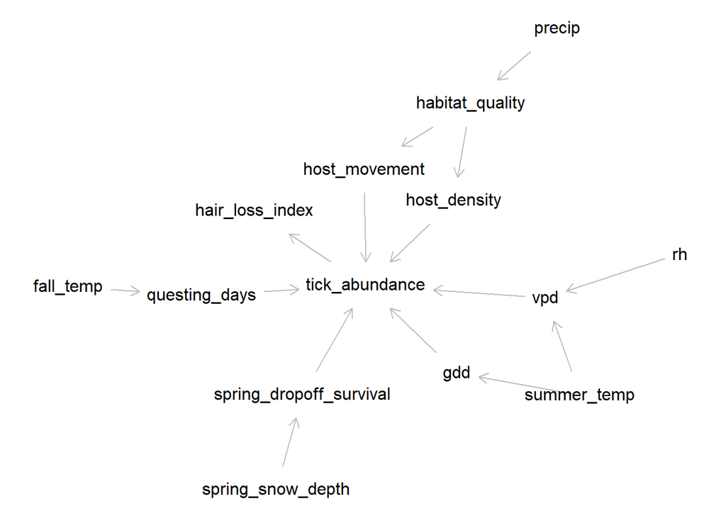

```r
wt_dag <- dagitty::dagitty("
dag {
  summer_temp -> gdd
  summer_temp -> vpd
  rh -> vpd

  precip -> habitat_quality

  fall_temp -> questing_days
  spring_snow_depth -> spring_dropoff_survival

  habitat_quality -> host_density
  habitat_quality -> host_movement

  gdd -> tick_abundance
  vpd -> tick_abundance
  questing_days -> tick_abundance
  spring_dropoff_survival -> tick_abundance

  host_density -> tick_abundance
  host_movement -> tick_abundance

  tick_abundance -> hair_loss_index
}
")

plot(wt_dag)
```

### 8.1 Quick adjustment set example (just to show the workflow)

Let’s say the question is:

> What is the causal effect of `fall_temp` on `hair_loss_index`?

```r
adjustmentSets(
  wt_dag,
  exposure = "fall_temp",
  outcome = "hair_loss_index"
)
```

```
##  {}
```

Just like any analysis technique, DAGs are only as useful as the information you have on your system. There are a grand total of 2 papers on climate associations with winter ticks specifically (not hair loss on moose as a proxy), which means the environmental variables used here are based on what I know from other systems and from experiments I got to do in the middle of my phd. Plenty of y’all have access to really cool experimental or observational data in the literature for your system that you can mine for relevant variables, but at the end of the day YOU will end up being the person who decides what goes into the model and that might be based on ecology or environmental data access constraints…if you can’t include ecology you think is relevant (no host data or bad host data), then you’ll have to live with the limitation that places on your inferential ability…the great things about DAGs is that they inform your leader on what you know to be important and what you really could include!

## 9 NOW YOU TRY (FRANTIC TEACHER NOISES): build your own DAG

Up to this point we’ve been working with a winter tick example that I wrote for you.  
Now it’s your turn to write the **full causal story** for your own system.

Most of you are working on **ticks, chiggers, or biting flies** somewhere in Ohio or the surrounding region. Even if the details differ, these systems almost always involve the same big categories of drivers: *Julia, idk where to start with fish, but I trust you do!* Environmental drivers

- temperature
- humidity / VPD
- precipitation
- snow conditions
- seasonality

Landscape variables

- forest cover
- edge habitat
- land use
- host habitat quality

Host ecology

- host density
- host movement
- host species composition

Parasite outcomes

- vector abundance
- infection prevalence
- biting rate
- host health outcomes

The goal here is **not to build the “perfect” DAG**.

The goal is to make your **assumptions about how the system works explicit**.

If someone asked you:

> “Why did you include these covariates in your model?”

Your DAG should basically be the answer.

### 9.1 Step 1: Define your outcome

Pick one outcome variable that your study is trying to explain.

Examples:

- tick abundance
- chigger infestation rate
- fly biting rate
- pathogen prevalence

Write your outcome here:

**Outcome variable:**  
Your answer:

### 9.2 Step 2: Define your main exposure

Pick one variable whose effect you want to understand.

Examples:

- temperature
- habitat fragmentation
- host density
- precipitation

Write your exposure here:

**Exposure variable:**  
Your answer:

### 9.3 Step 3: Brainstorm the rest of the system

Now think about the **mechanistic story**.

Ask yourself:

- What environmental variables influence this system?
- What host processes matter?
- Are there intermediate processes between environment → outcome?

Some common examples:

```
Temperature → host activity → tick encounter rate (high temp, hosts slow down even if vectors active)
Forest cover → host density → vector abundance
Precipitation → vegetation → host and vector habitat quality
Humidity → vector survival
```

Write down **at least 6–10 variables** that belong in your system.

Your variables:

### 9.4 Step 4: Write the DAG in dagitty

Now we translate the ecological story into a DAG.

Use the template below and replace the node names and arrows with your own.

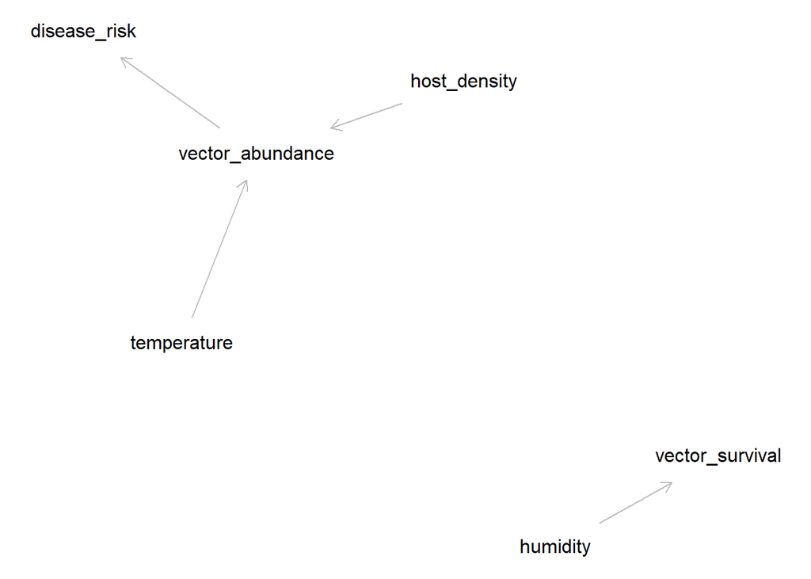

```r
my_dag <- dagitty::dagitty("
dag {
temperature -> vector_abundance
humidity -> vector_survival
host_density -> vector_abundance

vector_abundance -> disease_risk

}
")

plot(my_dag)
```

This should create a graph of your causal assumptions.

### 9.5 Step 5: Identify confounders

Now ask the key DAG question:

> Are there **backdoor paths** between your exposure and outcome?

If so, those variables are potential **confounders** that may need to be controlled.

Use the `adjustmentSets()` function:

```r
#adjustmentSets(
  #my_dag,
  #exposure = "your_exposure",
  #outcome = "your_outcome"
#)
```

Replace `"your_exposure"` and `"your_outcome"` with your actual variables.

## 10 Structure equation model

Structural Equation Models (SEMs) are a way to estimate **multiple linked regression relationships at the same time**. Instead of fitting one model for each response variable, SEMs allow us to estimate an entire **causal pathway network** in a single framework.

In other words, SEMs let us translate the **arrows in a DAG into statistical models**.

For example, if our DAG says:

Summer temperature → GDD → Tick abundance → Hair loss

an SEM allows us to estimate each of those relationships simultaneously while accounting for the structure of the system.

This can be useful when:

- ecological processes occur **in stages** (environment → host ecology → parasite dynamics → host health)
- variables act as both **responses and predictors** in different parts of the system
- we want to estimate **direct and indirect effects** of environmental drivers

Import example winter tick data for fitting an SEM below:

```r
dat <- read.csv("lab_7_data.csv")

summary(dat)
```

```
##        X              site             year    summer_temp     spring_temp
##  Min.   :  1.0   Min.   :  1.00   Min.   :1   Min.   :12.01   Min.   : 3.257
##  1st Qu.:150.8   1st Qu.: 30.75   1st Qu.:2   1st Qu.:16.68   1st Qu.: 8.546
##  Median :300.5   Median : 60.50   Median :3   Median :17.93   Median :10.027
##  Mean   :300.5   Mean   : 60.50   Mean   :3   Mean   :17.95   Mean   : 9.933
##  3rd Qu.:450.2   3rd Qu.: 90.25   3rd Qu.:4   3rd Qu.:19.29   3rd Qu.:11.322
##  Max.   :600.0   Max.   :120.00   Max.   :5   Max.   :24.46   Max.   :16.991
##    fall_temp            rh             precip        snow_depth
##  Min.   : 2.773   Min.   : 52.37   Min.   :128.0   Min.   : 5.703
##  1st Qu.: 6.687   1st Qu.: 69.91   1st Qu.:280.9   1st Qu.:39.433
##  Median : 7.957   Median : 75.05   Median :322.3   Median :49.283
##  Mean   : 8.017   Mean   : 75.05   Mean   :319.2   Mean   :49.539
##  3rd Qu.: 9.404   3rd Qu.: 80.58   3rd Qu.:357.4   3rd Qu.:60.048
##  Max.   :15.169   Max.   :102.77   Max.   :491.7   Max.   :97.618
##       gdd              vpd           questing_days    forest_cover
##  Min.   : 851.9   Min.   :-0.07407   Min.   :25.68   Min.   :0.2003
##  1st Qu.:1399.4   1st Qu.: 0.39374   1st Qu.:48.41   1st Qu.:0.3733
##  Median :1549.5   Median : 0.50554   Median :54.11   Median :0.5682
##  Mean   :1552.4   Mean   : 0.51582   Mean   :54.09   Mean   :0.5539
##  3rd Qu.:1702.1   3rd Qu.: 0.62452   3rd Qu.:59.44   3rd Qu.:0.7297
##  Max.   :2329.1   Max.   : 1.21658   Max.   :81.84   Max.   :0.8993
##   shrub_cover     habitat_quality     host_density     host_movement
##  Min.   :0.1008   Min.   :-3.04115   Min.   : 0.2178   Min.   : 4.394
##  1st Qu.:0.2368   1st Qu.:-0.67395   1st Qu.: 1.4761   1st Qu.:15.660
##  Median :0.3682   Median :-0.02278   Median : 2.7791   Median :17.643
##  Mean   :0.3559   Mean   : 0.00000   Mean   : 3.8628   Mean   :17.744
##  3rd Qu.:0.4747   3rd Qu.: 0.70109   3rd Qu.: 5.0047   3rd Qu.:19.904
##  Max.   :0.6000   Max.   : 2.60686   Max.   :32.3850   Max.   :27.662
##   egg_survival    larval_survival encounter_prob   tick_abundance
##  Min.   :0.5348   Min.   :1       Min.   :0.5330   Min.   :   1.0
##  1st Qu.:0.7510   1st Qu.:1       1st Qu.:0.7175   1st Qu.:  85.0
##  Median :0.7891   Median :1       Median :0.7948   Median : 187.5
##  Mean   :0.7829   Mean   :1       Mean   :0.7987   Mean   : 260.0
##  3rd Qu.:0.8218   3rd Qu.:1       3rd Qu.:0.8787   3rd Qu.: 372.0
##  Max.   :0.9063   Max.   :1       Max.   :1.0000   Max.   :1260.0
##  hair_loss_index
##  Min.   :0.02116
##  1st Qu.:0.05872
##  Median :0.08365
##  Mean   :0.12031
##  3rd Qu.:0.13879
##  Max.   :0.65555
```

### 10.1 Sanity check: do we have what we need?

This lab expects these columns to exist in `lab_7_data.csv`:

If your names differ, rename them here.

```r
# Example:
# names(dat)
# dat <- dat |>
#   rename(
#     spring_snow_depth = SnowDepth_spring,
#     fall_temp = Temp_fall
#   )
```

Okay, SEM time.

Is it simplified? yes.  
Is it good practice? also yes.

```r
sem_model2 <- "
  gdd ~ summer_temp
  vpd ~ summer_temp + rh
  habitat_quality ~ precip

  questing_days ~ fall_temp

  host_density ~ habitat_quality
  host_movement ~ habitat_quality

  tick_abundance ~ gdd + vpd + questing_days + host_density + host_movement
  hair_loss_index ~ tick_abundance
"

fit2 <- lavaan::sem(sem_model2, data = dat)
summary(fit2, standardized = TRUE, fit.measures = TRUE)
```

```
## lavaan 0.6-21 ended normally after 32 iterations
##
##   Estimator                                         ML
##   Optimization method                           NLMINB
##   Number of model parameters                        21
##
##   Number of observations                           600
##
## Model Test User Model:
##
##   Test statistic                                44.470
##   Degrees of freedom                                47
##   P-value (Chi-square)                           0.578
##
## Model Test Baseline Model:
##
##   Test statistic                              7462.714
##   Degrees of freedom                                60
##   P-value                                        0.000
##
## User Model versus Baseline Model:
##
##   Comparative Fit Index (CFI)                    1.000
##   Tucker-Lewis Index (TLI)                       1.000
##
## Loglikelihood and Information Criteria:
##
##   Loglikelihood user model (H0)              -9960.191
##   Loglikelihood unrestricted model (H1)      -9937.956
##
##   Akaike (AIC)                               19962.381
##   Bayesian (BIC)                             20054.717
##   Sample-size adjusted Bayesian (SABIC)      19988.048
##
## Root Mean Square Error of Approximation:
##
##   RMSEA                                          0.000
##   90 Percent confidence interval - lower         0.000
##   90 Percent confidence interval - upper         0.024
##   P-value H_0: RMSEA <= 0.050                    1.000
```

[output cut: 31 more lines]

```
##     host_density        4.867       NA                       4.867    0.075
##     host_movement      -4.264       NA                      -4.264   -0.055
##   hair_loss_index ~
##     tick_abundance      0.000       NA                       0.000    0.924
##
## Variances:
##                    Estimate   Std.Err  z-value  P(>|z|)   Std.lv   Std.all
##    .gdd              898.571       NA                     898.571    0.016
##    .vpd                0.000       NA                       0.000    0.015
##    .habitat_qualty     0.998       NA                       0.998    1.000
##    .questing_days     25.415       NA                      25.415    0.402
##    .host_density       4.493       NA                       4.493    0.340
##    .host_movement      9.004       NA                       9.004    0.952
##    .tick_abundance 55248.850       NA                   55248.850    0.981
##    .hair_loss_indx     0.002       NA                       0.002    0.146
```

### 11.1 Extract standardized path coefficients (aka: “which arrows matter most”)

```r
fit2_se <- lavaan::sem(sem_model2, data = dat, se = "robust")
summary(fit2_se, standardized = TRUE, fit.measures = TRUE)
```

```
## lavaan 0.6-21 ended normally after 32 iterations
##
##   Estimator                                         ML
##   Optimization method                           NLMINB
##   Number of model parameters                        21
##
##   Number of observations                           600
##
## Model Test User Model:
##
##   Test statistic                                44.470
##   Degrees of freedom                                47
##   P-value (Chi-square)                           0.578
##
## Model Test Baseline Model:
##
##   Test statistic                              7462.714
##   Degrees of freedom                                60
##   P-value                                        0.000
##
## User Model versus Baseline Model:
##
##   Comparative Fit Index (CFI)                    1.000
##   Tucker-Lewis Index (TLI)                       1.000
##
## Loglikelihood and Information Criteria:
##
##   Loglikelihood user model (H0)              -9960.191
##   Loglikelihood unrestricted model (H1)      -9937.956
##
##   Akaike (AIC)                               19962.381
##   Bayesian (BIC)                             20054.717
##   Sample-size adjusted Bayesian (SABIC)      19988.048
##
## Root Mean Square Error of Approximation:
##
##   RMSEA                                          0.000
##   90 Percent confidence interval - lower         0.000
##   90 Percent confidence interval - upper         0.024
##   P-value H_0: RMSEA <= 0.050                    1.000
```

[output cut: 31 more lines]

```
##     host_density        4.867       NA                       4.867    0.075
##     host_movement      -4.264       NA                      -4.264   -0.055
##   hair_loss_index ~
##     tick_abundance      0.000       NA                       0.000    0.924
##
## Variances:
##                    Estimate   Std.Err  z-value  P(>|z|)   Std.lv   Std.all
##    .gdd              898.571       NA                     898.571    0.016
##    .vpd                0.000       NA                       0.000    0.015
##    .habitat_qualty     0.998       NA                       0.998    1.000
##    .questing_days     25.415       NA                      25.415    0.402
##    .host_density       4.493       NA                       4.493    0.340
##    .host_movement      9.004       NA                       9.004    0.952
##    .tick_abundance 55248.850       NA                   55248.850    0.981
##    .hair_loss_indx     0.002       NA                       0.002    0.146
```

```r
pe <- lavaan::parameterEstimates(fit2_se, standardized = TRUE)
pe <- pe[pe$op == "~", ]
pe <- pe[order(-abs(pe$std.all)), ]
pe
```

```
##                lhs op             rhs     est se  z pvalue ci.lower ci.upper
## 1              gdd  ~     summer_temp 119.908 NA NA     NA       NA       NA
## 3              vpd  ~              rh  -0.021 NA NA     NA       NA       NA
## 13 hair_loss_index  ~  tick_abundance   0.000 NA NA     NA       NA       NA
## 6     host_density  ~ habitat_quality   2.959 NA NA     NA       NA       NA
## 5    questing_days  ~       fall_temp   3.113 NA NA     NA       NA       NA
## 2              vpd  ~     summer_temp   0.034 NA NA     NA       NA       NA
## 7    host_movement  ~ habitat_quality   0.677 NA NA     NA       NA       NA
## 8   tick_abundance  ~             gdd   0.105 NA NA     NA       NA       NA
## 11  tick_abundance  ~    host_density   4.867 NA NA     NA       NA       NA
## 12  tick_abundance  ~   host_movement  -4.264 NA NA     NA       NA       NA
## 10  tick_abundance  ~   questing_days   0.586 NA NA     NA       NA       NA
## 4  habitat_quality  ~          precip   0.000 NA NA     NA       NA       NA
## 9   tick_abundance  ~             vpd  -1.539 NA NA     NA       NA       NA
##     std.lv std.all std.nox
## 1  119.908   0.992   0.503
## 3   -0.021  -0.946  -0.119
## 13   0.000   0.924   0.924
## 6    2.959   0.813   0.813
## 5    3.113   0.774   0.391
## 2    0.034   0.374   0.190
## 7    0.677   0.220   0.220
## 8    0.105   0.106   0.106
## 11   4.867   0.075   0.075
## 12  -4.264  -0.055  -0.055
## 10   0.586   0.020   0.020
## 4    0.000   0.014   0.000
## 9   -1.539  -0.001  -0.001
```

## 12 Fun fact: you should not have empty values for everything…the simulated data does not have any variation so all our vars collapsed…womp womp

## 13 Interpretation prompts (don’t skip these)

- Which seasonal pathway is strongest for tick abundance?
  - summer heat (GDD)?
  - dryness (VPD)?
  - fall questing window?
  - spring snow effects?
- Do any signs surprise you?
  - If yes: is that a **data simulation** thing, a **model structure** thing, or does it force you to rethink the causal story?
- What would you add for a more realistic system?
  - spatial gradients (latitude/elevation)
  - sampling effort / observation bias (this is huge in real data)
  - host condition / nutrition
  - host species composition

## 14 Final takeaway

A DAG is a way to turn your ecological story into a testable model plan.

If you can’t draw your causal assumptions, you probably can’t justify your covariates. And if you can’t justify your covariates… you’re just doing vibes-based regression.

(And yes, I have absolutely done vibes-based regression before. We are healing.)

One last point: using a DAG to decide which variables belong in a model is very different from simply throwing a bunch of predictors into a model and letting something like AIC decide which ones “win.” AIC is great for comparing models, but it doesn’t know anything about causality — it will happily select models that include variables that create spurious relationships or control for the wrong parts of a system. By starting with a DAG, we force ourselves to write down the ecological story first. That helps us avoid bad controls, identify important confounders, and interpret statistical relationships in a way that actually reflects the biology of the system rather than just the structure of the dataset/what variables we have on hand.